# R - Assignment Mod 2 Week 3

Rajkumar Conjeevaram Mohan

02/03/2022

```r
# 1. Answer each question using in words/paragraph.
# 2. DO NOT use comments inside code blocks (like here) to answer anything. Those are for notes between coders/self. They
# will be ignored, and not counted as answers.
# 3. Keep the line/option    knitr::opts_chunk$set(warning = F, results = "hide", message = F)
# You can temporarily turn this on/off and use other option while you are working on the homework if it helps.
# The submitted work should have this option selected instead.
# 4. All charts/graphs/tables should have appropriate captions.
```

# HW - Module 2 week 03

## Question 1. Import

**Read in the file with all the baseball players height, weight and age info (BaseballHeightWeight.csv) as a dataframe and save it as baseball. Then display the structure of the dataframe.**

```r
# This is coder's comments
# Since my RMD and csv files are in the same working directory, I do not need to give the full path to the csv file. Alternatively, you can use the functions getwd() and setwd() to handle it.

#baseball <- data.frame(read.csv("BaseballHeightWeight.csv"))
baseball <- read.csv(file = "BaseballHeightWeight.csv",
                     header = T,
                     sep=",",
                     #row.names=1,
                     #fill=T, # I am disabling this as it turns out we are playing with Null values at some point
                     strip.white = T,
                     blank.lines.skip=T,
                     allowEscapes=F)

baseball <- data.frame(baseball)
# baseballdf <- read.csv("BaseballHeightWeight.csv")
# You can compare the two above lines, and look at the object called baseball in the "Environment" on the upper right.
# Turns out either method gives the same result. In some cases (depending on the .csv file), they might differ. To be safe, I usually use data.frame( ) afterwards.
```

The function `read.csv()` was used to load the dataframe. In addition, we can see that there are 1034 in the dataframe. Note that `read.csv()` is just one of the many functions you can use to import data files.

```r
# need results="asis" to overwrite the default, and show the result block in Html/pdf
str(baseball)
```

[output not shown]

I have yet to find a simple and easy way to “pretty-print” such structure in R output. Most of the time we don’t need to show these to the readers though.

## Question 2. Head and Tail

**Print out the first 5 and the last 3 rows of the dataframe.**

The `head()` and `tail()` functions are what we need.

```r
# Probably looks more neat
rmarkdown::paged_table(head(baseball, n=5))
```

|  | Name | Team | Position | Height.inches. | Weight.pounds. | Age |
| --- | --- | --- | --- | --- | --- | --- |
| 1 | Adam_Donachie | BAL | Catcher | 74 | 180 | 23.0 |
| 2 | Paul_Bako | BAL | Catcher | 74 | 215 | 34.7 |
| 3 | Ramon_Hernandez | BAL | Catcher | 72 | 210 | 30.8 |
| 4 | Kevin_Millar | BAL | First_Baseman | 72 | 210 | 35.4 |
| 5 | Chris_Gomez | BAL | First_Baseman | 73 | 188 | 35.7 |

```r
rmarkdown::paged_table(tail(baseball, n=3))
```

|  | Name | Team | Position | Height.inches. | Weight.pounds. | Age |
| --- | --- | --- | --- | --- | --- | --- |
| 1032 | Chris_Narveson | STL | Relief_Pitcher | 75 | 205 | 25.2 |
| 1033 | Randy_Keisler | STL | Relief_Pitcher | 75 | 190 | 31.0 |
| 1034 | Josh_Kinney | STL | Relief_Pitcher | 73 | 195 | 27.9 |

But we should use the modified version in `ezids` from now on:

```r
# you can use "markup" or "asis" here to get the same result.
xkabledplyhead(baseball, 5, "The first 5 rows using `xkabledplyhead` function." )
```

The first 5 rows using `xkabledplyhead` function.

| Name | Team | Position | Height.inches. | Weight.pounds. | Age |
| --- | --- | --- | --- | --- | --- |
| Adam_Donachie | BAL | Catcher | 74 | 180 | 23.0 |
| Paul_Bako | BAL | Catcher | 74 | 215 | 34.7 |
| Ramon_Hernandez | BAL | Catcher | 72 | 210 | 30.8 |
| Kevin_Millar | BAL | First_Baseman | 72 | 210 | 35.4 |
| Chris_Gomez | BAL | First_Baseman | 73 | 188 | 35.7 |

and the last three rows:

```r
# you can use "markup" or "asis" here to get the same result.
xkabledplytail(baseball, 3, "The last 3 rows using `xkabledplytail` function." )
```

The last 3 rows using `xkabledplytail` function.

|  | Name | Team | Position | Height.inches. | Weight.pounds. | Age |
| --- | --- | --- | --- | --- | --- | --- |
| 1032 | Chris_Narveson | STL | Relief_Pitcher | 75 | 205 | 25.2 |
| 1033 | Randy_Keisler | STL | Relief_Pitcher | 75 | 190 | 31.0 |
| 1034 | Josh_Kinney | STL | Relief_Pitcher | 73 | 195 | 27.9 |

## Question 3. Header change

**Change the headers/column names from Weight.pounds. to weight, from Height.inches. to height, and Age to age.**

```r
baseball.colnames <- colnames(baseball)
baseball.colnames[c(4,5,6)] <- c("Height", "Weight", "age")
colnames(baseball) <- baseball.colnames
```

## Question 4. Head again

**Print out the first two lines again to see the new column names.**

```r
xkabledplyhead(baseball, 2)
```

Head

| Name | Team | Position | Height | Weight | age |
| --- | --- | --- | --- | --- | --- |
| Adam_Donachie | BAL | Catcher | 74 | 180 | 23.0 |
| Paul_Bako | BAL | Catcher | 74 | 215 | 34.7 |

## Question 5. Summary

**Find the statistics (summary) of the heights, weights, and ages of the players. Using complete sentences, give the reader these summary.**

```r
tmp_s <- xkablesummary(baseball)
print(tmp_s)
```

Table: Statistics summary.

|  | Name | Team | Position | Height | Weight | age |
| --- | --- | --- | --- | --- | --- | --- |
| Min | Length:1034 | Length:1034 | Length:1034 | Min. :67.0 | Min. :150 | Min. :20.9 |
| Q1 | Class :character | Class :character | Class :character | 1st Qu.:72.0 | 1st Qu.:187 | 1st Qu.:25.4 |
| Median | Mode :character | Mode :character | Mode :character | Median :74.0 | Median :200 | Median :27.9 |
| Mean | NA | NA | NA | Mean :73.7 | Mean :202 | Mean :28.7 |
| Q3 | NA | NA | NA | 3rd Qu.:75.0 | 3rd Qu.:215 | 3rd Qu.:31.2 |
| Max | NA | NA | NA | Max. :83.0 | Max. :290 | Max. :48.5 |
| NA | NA | NA | NA | NA | NA’s :1 | NA |

```r
# I have given %.2f for age and height instead of %.1f since I can't for now
# look at every possible value in the list to verify.
```

## Question 6. Subset

**You should find an issue with the weight data with an NA value. Use the `subset( )` function, select that data point (save as shyboy) and find out who the shy boy was.**

```r
shyboy.index <- which(is.na(baseball[, "Weight"]))
shyboy <- baseball[shyboy.index, ]
sprintf("It turns out the shyboy was %s", shyboy$Name)
```

[1] “It turns out the shyboy was Kirk_Saarloos”

## Question 7. Remove Shyboy

**Remove shyboy from baseball, and then show the number of observations of the cleaned up dataframe baseball.**

```r
baseball <- baseball[-shyboy.index, ]
print(nrow(baseball))
```

[1] 1033

## Question 8. Boxplot

**Make a quick boxplot of the weight of the players. Use the `title( )` function immediately to add a title to the chart. (Try color #0000FF for blue.)**

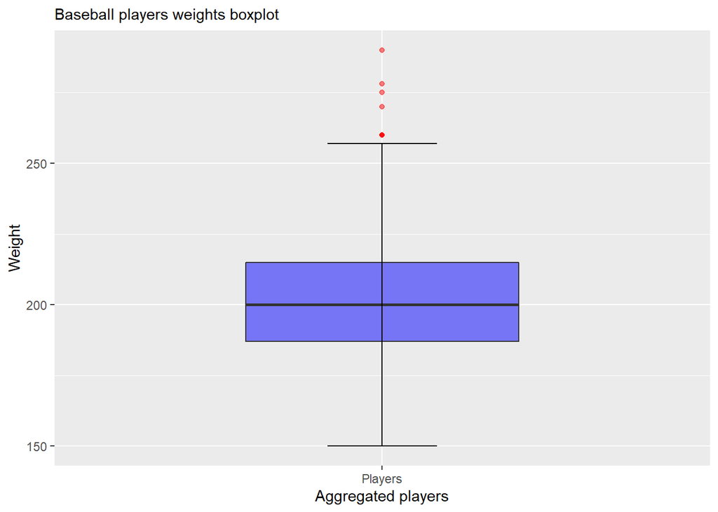

```r
ggplot(baseball, aes(x='Players', y=Weight)) +
geom_boxplot(width=0.5, lwd=0.5, outlier.color='red', fill='#0000FF', alpha=0.5) +
stat_boxplot(geom = "errorbar", # Boxplot with error bars
                    width = 0.2) +
labs(subtitle="Baseball players weights boxplot") +
xlab("Aggregated players") +
ylab("Weight")
```

## Question 9. Histogram

**Make a histogram of the weight of the players. Try color ‘green’ this time. The function understands the word ‘green’ just fine. Give it a better title than the default. Does the distribution looks normal?**

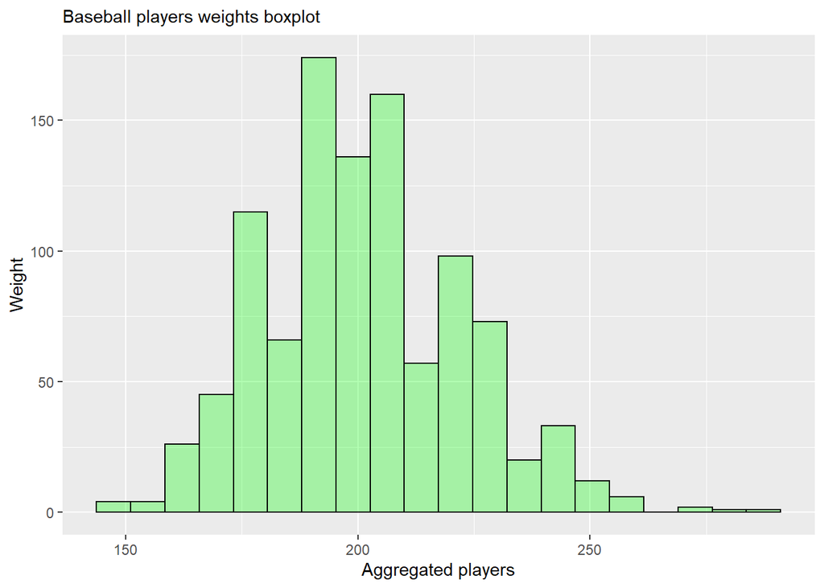

```r
ggplot(baseball, aes(x=Weight)) +
# I had to give bins=20 since it was throwing some warning
geom_histogram(fill='green', color='black', alpha=0.3, bins=20) +
labs(subtitle="Baseball players weights boxplot") +
xlab("Aggregated players") +
ylab("Weight")
```

The distribution does appear normal.

## Question 10. Scatterplot

**Use ggplot, make a plot with weights vs heights of the players, color by Teams. Give it an appropriate title.**

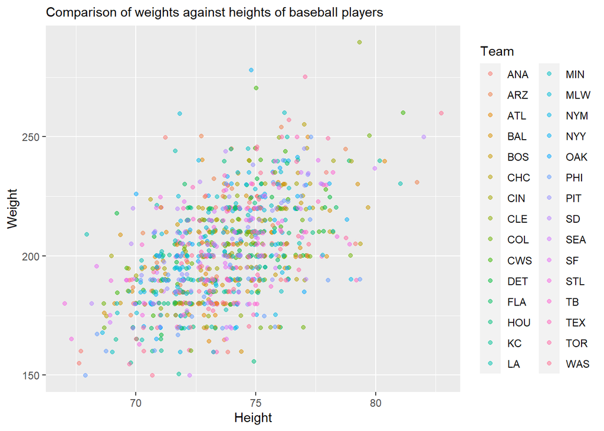

```r
ggplot(baseball, aes(x=Height, y=Weight)) +
geom_jitter(aes(color=Team), alpha=0.5) +
xlab('Height') +
ylab('Weight') +
labs(subtitle='Comparison of weights against heights of baseball players')
```

## Question 11. Plot by age

**Make a plot with weights vs heights of the players, color by age.**

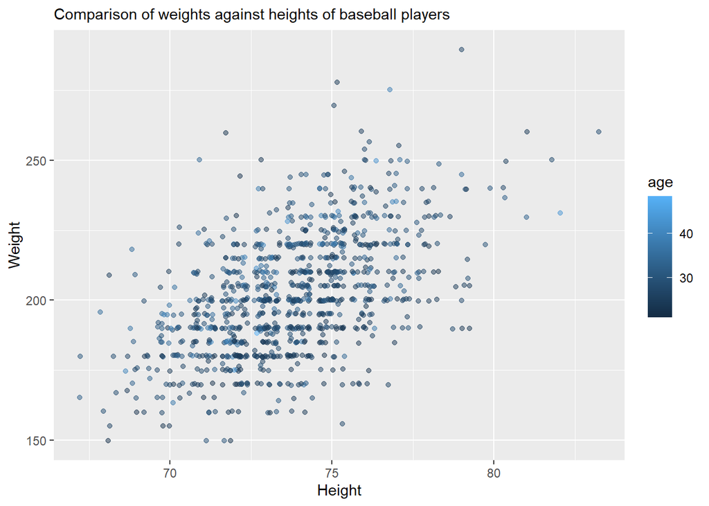

```r
ggplot(baseball, aes(x=Height, y=Weight, col=age)) +
geom_jitter(alpha=0.5) +
labs(subtitle='Comparison of weights against heights of baseball players') +
xlab('Height') +
ylab('Weight')
```

## Question 12. Team Washington

**Obtain a subset of the data with only Team Washington. Using complete sentences, give the number of players in Team Washington.**

```r
subset.was <- baseball[baseball[, "Team"] == "WAS", ]
sprintf("There are %d baseball players who play for team Washington (WAS)", nrow(subset.was))
```

[1] “There are 36 baseball players who play for team Washington (WAS)”

## Question 13. Old Team Washington

**Obtain another subset with Team Washington and only players older than 28. How many are there in this veteran group?**

```r
subset.was_over_28 <- baseball[baseball[, "Team"] == "WAS" & baseball[, "age"] > 28, ]
sprintf("There are %d baseball players who are over 28 years old and play for team Washington (WAS)", nrow(subset.was_over_28))
```

[1] “There are 14 baseball players who are over 28 years old and play for team Washington (WAS)”